# Power 4 Bullpen Matchup Calculator

A MAC-style similar-pitch framework using NCAA TrackMan data

Author

Andy Lucas

Published

September 25, 2026

```r
library(data.table)
library(dplyr)
library(tidyr)
library(ggplot2)
library(knitr)
library(lubridate)
library(stringr)
library(shiny)
library(DT)

if (!exists("params")) {
  params <- list(
    validation_start = "2026-04-15",
    similarity_threshold = 1.50,
    similarity_thresholds_to_test = c(1.00, 1.50, 2.00),
    validation_sample_n = 2500,
    shrinkage_pitches = 50,
    weight_2025 = 1,
    weight_2026 = 2,
    minimum_similar_pitches = 25,
    minimum_pitcher_pitches = 50,
    minimum_matchup_coverage = 0.50)}

set.seed(42)
path_2025 <- params$data_path_2025
path_2026 <- params$data_path_2026
validation_start <- as.Date(params$validation_start)

if (!file.exists(path_2025) || !file.exists(path_2026)) {
  stop("Set data_path_2025 and data_path_2026 in the document parameters before rendering.")}

# Attributes the hitter can perceive. Location is retained for reporting only.
similarity_features <- c(
  "RelSpeed", "InducedVertBreak", "HorzBreak",
  "SpinRate", "RelHeight", "RelSide")
```

# Project overview

This project builds an interpretable bullpen matchup tool from NCAA TrackMan data. It compares a pitcher’s current arsenal with pitch shapes an opposing hitter previously faced, measures how the hitter performed against those comparable pitches, and combines the results using the pitcher’s actual usage.

The primary output is estimated context-neutral run value per 100 pitches (RV/100). Lower values favor the pitcher. Supporting whiff rate, hard-hit rate, wOBA, sample size, and similarity coverage explain each recommendation.

## Research question

> Given an available bullpen and an opposing hitter or lineup, which pitcher’s current arsenal most closely aligns with pitch shapes that have previously suppressed those hitters?

# Method

This analysis adapts the Matchup Analysis Calculator approach described by Chap Cunningham and Zack Aisen: https://medium.com/@chapcunningham28/mac-matchup-analysis-calculator-dfa259603a47.

For a selected pitcher, it defines the pitcher’s current 2026 shapes, standardizes velocity, movement, spin and release point, finds pitches the hitter previously saw within a Euclidean-distance threshold, and reports estimated run value per 100 pitches, whiff rate, hard-hit rate and wOBA. Pitch-family results are weighted by the selected pitcher’s usage.

The model uses 2025 as its historical foundation, weights early-2026 pitches more heavily, and reserves pitches on or after 2026-04-15 for validation. Spin axis is excluded because it is unavailable. Plate location is excluded from similarity because it describes execution rather than intrinsic pitch shape.

# Read and prepare the TrackMan files

```r
required_columns <- c(
  "Date", "Season", "Pitcher", "PitcherTeam", "PitcherThrows",
  "Batter", "BatterTeam", "BatterSide", "TaggedPitchType",
  "AutoPitchType", "PitchCall", "PlayResult", "KorBB", "Balls",
  "Strikes", "RelSpeed", "SpinRate", "RelHeight", "RelSide",
  "Extension", "InducedVertBreak", "HorzBreak", "PlateLocHeight",
  "PlateLocSide", "ExitSpeed", "Angle", "HomeTeam", "AwayTeam",
  "TopBottom", "GameID", "PlayID")

read_trackman <- function(path, season_label) {
  available <- names(fread(path, nrows = 0, showProgress = FALSE))
  missing <- setdiff(required_columns, available)
  if (length(missing) > 0) {
    stop("Missing required columns in ", path, ": ", paste(missing, collapse = ", "))}
  fread(
    path, select = required_columns, showProgress = TRUE,
    na.strings = c("", "NA", "NaN", "null")
  ) %>% mutate(SourceSeason = season_label)}

raw_2025 <- read_trackman(path_2025, 2025L)
raw_2026 <- read_trackman(path_2026, 2026L)
```

```r
normalize_player <- function(x) {
  x %>% str_to_lower() %>% str_replace_all("[^a-z0-9]+", " ") %>% str_squish()}

pitch_family <- function(tagged, auto) {
  pitch <- if_else(is.na(tagged) | tagged %in% c("Undefined", "Other"), auto, tagged)
  pitch <- str_to_lower(coalesce(pitch, "undefined"))
  case_when(
    pitch %in% c("fastball", "fast ball", "fourseamfastball", "four-seam") ~ "Four-seam",
    pitch %in% c("sinker", "twoseamfastball", "oneseamfastball", "two-seam") ~ "Sinker",
    pitch %in% c("slider", "cutter", "sweeper") ~ "Slider/Cutter",
    pitch %in% c("curveball", "curve", "knuckle curve") ~ "Curveball",
    pitch %in% c("changeup", "change up", "splitter", "split-finger") ~ "Offspeed",
    TRUE ~ NA_character_)}

prepare_trackman <- function(df) {
  df %>% mutate(
    GameDate = as.Date(ymd_hms(Date, quiet = TRUE, tz = "UTC")),
    PitcherKey = normalize_player(Pitcher),
    BatterKey = normalize_player(Batter),
    PitchFamily = pitch_family(TaggedPitchType, AutoPitchType),
    PitcherThrows = case_when(
      str_to_lower(PitcherThrows) == "right" ~ "R",
      str_to_lower(PitcherThrows) == "left" ~ "L",
      TRUE ~ NA_character_),
    BatterSide = case_when(
      str_to_lower(BatterSide) == "right" ~ "R",
      str_to_lower(BatterSide) == "left" ~ "L",
      TRUE ~ NA_character_),
    Balls = as.integer(Balls),
    Strikes = as.integer(Strikes),
    RecencyWeight = if_else(SourceSeason == 2026L, params$weight_2026, params$weight_2025))}

clean_trackman <- function(df) {
  df %>% filter(
    !is.na(PitcherKey), PitcherKey != "", !is.na(BatterKey), BatterKey != "",
    !is.na(PitcherThrows), !is.na(BatterSide), !is.na(PitchCall), !is.na(PitchFamily),
    if_all(all_of(similarity_features), ~ !is.na(.x)),
    between(Balls, 0, 3), between(Strikes, 0, 2),
    between(RelSpeed, 55, 105), between(SpinRate, 500, 4000),
    between(RelHeight, 2, 8), between(RelSide, -5, 5),
    between(InducedVertBreak, -35, 35), between(HorzBreak, -35, 35),
    PitchCall %in% c(
      "StrikeSwinging", "StrikeCalled", "Strikecalled", "AutomaticStrike",
      "FoulBallNotFieldable", "FoulBallFieldable", "FoulBall",
      "BallCalled", "BallinDirt", "AutomaticBall", "BallIntentional",
      "BallIntentional ", "HitByPitch", "InPlay"))}

prepared_2025 <- prepare_trackman(raw_2025)
prepared_2026 <- prepare_trackman(raw_2026)
clean_2025 <- clean_trackman(prepared_2025)
clean_2026 <- clean_trackman(prepared_2026)

quality_summary <- tibble(
  Season = c(2025, 2026),
  RawRows = c(nrow(raw_2025), nrow(raw_2026)),
  ModelRows = c(nrow(clean_2025), nrow(clean_2026))
) %>% mutate(ExcludedRows = RawRows - ModelRows, ModelRowPct = ModelRows / RawRows)
kable(quality_summary, digits = 3)
```

| Season | RawRows | ModelRows | ExcludedRows | ModelRowPct |
| --- | --- | --- | --- | --- |
| 2025 | 933967 | 627806 | 306161 | 0.672 |
| 2026 | 972700 | 657098 | 315602 | 0.676 |

# Estimate context-neutral pitch run value

Because complete base occupancy is unavailable, the analysis estimates run value from the count. Terminal outcomes use approximate linear run weights: out/strikeout `0.00`, walk/HBP `0.33`, single/error `0.47`, double `0.78`, triple `1.09`, and home run `1.40`. The expected value of every ball-strike count is learned from development data with Markov value iteration. Pitch RV is the resulting count or terminal value minus the value before the pitch.

```r
add_transitions <- function(df) {
  ball_call <- df$PitchCall %in% c(
    "BallCalled", "BallinDirt", "AutomaticBall", "BallIntentional", "BallIntentional ")
  strike_call <- df$PitchCall %in% c(
    "StrikeSwinging", "StrikeCalled", "Strikecalled", "AutomaticStrike")
  foul_call <- df$PitchCall %in% c(
    "FoulBallNotFieldable", "FoulBallFieldable", "FoulBall")
  walk <- df$KorBB == "Walk" | df$PitchCall %in% c("BallIntentional", "BallIntentional ") |
    (ball_call & df$Balls == 3)
  strikeout <- df$KorBB == "Strikeout" | (strike_call & df$Strikes == 2)
  hbp <- df$PitchCall == "HitByPitch"
  in_play <- df$PitchCall == "InPlay"
  terminal <- walk | strikeout | hbp | in_play

  terminal_value <- case_when(
    walk | hbp ~ 0.33,
    in_play & df$PlayResult %in% c("Single", "Single ", "Error") ~ 0.47,
    in_play & df$PlayResult == "Double" ~ 0.78,
    in_play & df$PlayResult == "Triple" ~ 1.09,
    in_play & df$PlayResult == "HomeRun" ~ 1.40,
    TRUE ~ 0)
  woba_value <- case_when(
    walk | hbp ~ 0.70,
    in_play & df$PlayResult %in% c("Single", "Single ", "Error") ~ 0.90,
    in_play & df$PlayResult == "Double" ~ 1.25,
    in_play & df$PlayResult == "Triple" ~ 1.60,
    in_play & df$PlayResult == "HomeRun" ~ 2.00,
    TRUE ~ 0)

  next_balls <- df$Balls
  next_strikes <- df$Strikes
  next_balls[ball_call & !terminal] <- next_balls[ball_call & !terminal] + 1L
  next_strikes[strike_call & !terminal] <- next_strikes[strike_call & !terminal] + 1L
  next_strikes[foul_call & df$Strikes < 2 & !terminal] <-
    next_strikes[foul_call & df$Strikes < 2 & !terminal] + 1L

  df %>% mutate(
    State = paste0(Balls, "-", Strikes),
    IsTerminal = terminal,
    TerminalValue = terminal_value,
    NextState = if_else(terminal, NA_character_, paste0(next_balls, "-", next_strikes)),
    IsSwing = PitchCall %in% c(
      "StrikeSwinging", "FoulBallNotFieldable", "FoulBallFieldable", "FoulBall", "InPlay"),
    IsWhiff = PitchCall == "StrikeSwinging",
    IsBIP = in_play,
    IsHardHit = in_play & !is.na(ExitSpeed) & ExitSpeed >= 95,
    IsPAEnd = terminal,
    WOBAValue = woba_value)}

estimate_count_values <- function(df, tolerance = 1e-10, max_iter = 1000) {
  states <- as.vector(outer(0:3, 0:2, paste, sep = "-"))
  values <- setNames(rep(0.30, length(states)), states)
  for (iteration in seq_len(max_iter)) {
    continuation <- values[df$NextState]
    target <- ifelse(df$IsTerminal, df$TerminalValue, continuation)
    estimates <- tibble(State = df$State, Target = target) %>%
      group_by(State) %>% summarise(Value = mean(Target, na.rm = TRUE), .groups = "drop")
    updated <- values
    updated[estimates$State] <- estimates$Value
    if (max(abs(updated - values), na.rm = TRUE) < tolerance) {
      values <- updated
      break}
    values <- updated}
  values}

development_2026_dates <- clean_2026 %>% filter(GameDate < validation_start)
development_base <- bind_rows(clean_2025, development_2026_dates) %>% add_transitions()
validation_base <- clean_2026 %>% filter(GameDate >= validation_start) %>% add_transitions()
count_values <- estimate_count_values(development_base)

add_pitch_rv <- function(df, values) {
  resulting_value <- ifelse(df$IsTerminal, df$TerminalValue, values[df$NextState])
  df %>% mutate(PitchRV = resulting_value - values[State])}

development_base <- add_pitch_rv(development_base, count_values)
validation_base <- add_pitch_rv(validation_base, count_values)
count_value_table <- tibble(Count = names(count_values), ExpectedRuns = as.numeric(count_values)) %>%
  arrange(Count)
kable(count_value_table, digits = 3)
```

| Count | ExpectedRuns |
| --- | --- |
| 0-0 | 0.206 |
| 0-1 | 0.173 |
| 0-2 | 0.127 |
| 1-0 | 0.228 |
| 1-1 | 0.192 |
| 1-2 | 0.141 |
| 2-0 | 0.258 |
| 2-1 | 0.221 |
| 2-2 | 0.166 |
| 3-0 | 0.294 |
| 3-1 | 0.268 |
| 3-2 | 0.214 |

# Standardize pitch shapes

Means and standard deviations come only from clean 2025 pitches. The same transformation is applied to 2026 data, preventing held-out information from affecting similarity distances.

```r
training_2025 <- development_base %>% filter(SourceSeason == 2025)
feature_center <- vapply(
  as.data.frame(training_2025)[, similarity_features, drop = FALSE],
  mean, numeric(1), na.rm = TRUE)
feature_scale <- vapply(
  as.data.frame(training_2025)[, similarity_features, drop = FALSE],
  sd, numeric(1), na.rm = TRUE)
feature_scale[!is.finite(feature_scale) | feature_scale == 0] <- 1

standardize_shapes <- function(df) {
  output <- df
  for (feature in similarity_features) {
    output[[paste0("Z_", feature)]] <-
      (output[[feature]] - feature_center[[feature]]) / feature_scale[[feature]]}
  output}

z_features <- paste0("Z_", similarity_features)
development <- standardize_shapes(development_base)
validation <- standardize_shapes(validation_base)
current_arsenal_data <- standardize_shapes(add_pitch_rv(add_transitions(clean_2026), count_values))

# The app offers only hitters who appear in 2026. Normalize spelling and retain
# the most recently observed 2026 team for a clear, unique selector label.
hitter_directory <- clean_2026 %>%
  filter(!is.na(BatterKey), BatterKey != "", !is.na(Batter), Batter != "") %>%
  arrange(BatterKey, desc(GameDate), desc(!is.na(BatterTeam) & BatterTeam != "")) %>%
  group_by(BatterKey) %>%
  summarise(
    Batter = str_squish(first(Batter)),
    CurrentTeam = first(BatterTeam[!is.na(BatterTeam) & BatterTeam != ""], default = "Unknown"),
    Pitches2026 = n(),
    .groups = "drop") %>%
  arrange(Batter)
```

# Pitcher-specific similar-pitch analysis

Each pitcher is represented by the average standardized shape and usage of each pitch family. For every target shape, the calculator searches the hitter’s history for pitches from the same pitcher hand and family within the Euclidean threshold. Hitter RV is pulled toward the league pitch-family average using 50 weighted pitches.

```r
pitch_family_priors <- development %>%
  group_by(PitcherThrows, PitchFamily) %>%
  summarise(PriorRV = weighted.mean(PitchRV, RecencyWeight, na.rm = TRUE), .groups = "drop")

make_target_shapes <- function(
  pitcher_name, pitcher_team = NULL, target_data = current_arsenal_data) {
  pitcher_key <- normalize_player(pitcher_name)
  pitcher_pitches <- target_data %>% filter(PitcherKey == pitcher_key)
  if (!is.null(pitcher_team)) {
    pitcher_pitches <- pitcher_pitches %>% filter(PitcherTeam == pitcher_team)}
  if (nrow(pitcher_pitches) == 0) {
    stop("No qualifying 2026 pitches found for pitcher: ", pitcher_name)}
  total <- nrow(pitcher_pitches)
  pitcher_pitches %>%
    group_by(PitcherKey, Pitcher, PitcherTeam, PitcherThrows, PitchFamily) %>%
    summarise(
      TargetPitches = n(), Usage = n() / total,
      across(all_of(z_features), function(x) mean(x, na.rm = TRUE)), .groups = "drop")}

weighted_rate <- function(x, w) {
  valid <- !is.na(x) & !is.na(w)
  if (!any(valid)) return(NA_real_)
  weighted.mean(as.numeric(x[valid]), w[valid])}

mac_matchup <- function(
  pitcher_name, batter_name, pitcher_team = NULL,
  threshold = params$similarity_threshold,
  history = development, target_data = current_arsenal_data) {
  batter_key <- normalize_player(batter_name)
  hitter_history <- history %>% filter(BatterKey == batter_key)
  if (nrow(hitter_history) == 0) stop("No qualifying history found for batter: ", batter_name)

  batter_display <- hitter_directory %>%
    filter(BatterKey == batter_key) %>%
    pull(Batter)
  if (length(batter_display) == 0) batter_display <- batter_name

  shapes <- make_target_shapes(pitcher_name, pitcher_team, target_data)
  detail <- vector("list", nrow(shapes))
  for (i in seq_len(nrow(shapes))) {
    candidate <- hitter_history %>% filter(
      PitcherThrows == shapes$PitcherThrows[i], PitchFamily == shapes$PitchFamily[i])
    if (nrow(candidate) > 0) {
      x <- as.matrix(as.data.frame(candidate)[, z_features, drop = FALSE])
      target <- as.numeric(as.data.frame(shapes)[i, z_features, drop = FALSE])
      distance <- sqrt(rowSums((x - matrix(target, nrow(x), length(target), byrow = TRUE))^2))
      similar <- candidate[distance <= threshold, ]} else {
      distance <- numeric()
      similar <- candidate}

    prior <- pitch_family_priors %>% filter(
      PitcherThrows == shapes$PitcherThrows[i], PitchFamily == shapes$PitchFamily[i]) %>% pull(PriorRV)
    if (length(prior) == 0) prior <- mean(history$PitchRV, na.rm = TRUE)

    weighted_n <- sum(similar$RecencyWeight)
    observed_rv <- if (nrow(similar) > 0) {
      weighted.mean(similar$PitchRV, similar$RecencyWeight, na.rm = TRUE)} else prior
    shrinkage_weight <- weighted_n / (weighted_n + params$shrinkage_pitches)
    adjusted_rv <- shrinkage_weight * observed_rv + (1 - shrinkage_weight) * prior
    pa_ends <- sum(similar$IsPAEnd)

    detail[[i]] <- shapes[i, ] %>% mutate(
      Batter = batter_display[[1]],
      SimilarPitches = nrow(similar),
      WeightedSimilarPitches = weighted_n,
      MeanDistance = if (nrow(similar) > 0) mean(distance[distance <= threshold]) else NA_real_,
      RV100 = 100 * adjusted_rv,
      WhiffRate = weighted_rate(similar$IsWhiff[similar$IsSwing], similar$RecencyWeight[similar$IsSwing]),
      HardHitRate = weighted_rate(similar$IsHardHit[similar$IsBIP], similar$RecencyWeight[similar$IsBIP]),
      WOBA = if (pa_ends > 0) sum(similar$WOBAValue[similar$IsPAEnd]) / pa_ends else NA_real_,
      SampleQualified = SimilarPitches >= params$minimum_similar_pitches)}

  detail <- bind_rows(detail)
  overall <- detail %>% summarise(
    Pitcher = first(Pitcher), PitcherTeam = first(PitcherTeam), Batter = first(Batter),
    ProjectedRV100 = sum(Usage * RV100),
    SimilarityCoverage = sum(Usage * SampleQualified),
    SimilarPitches = sum(SimilarPitches), PitcherPitches = sum(TargetPitches))
  list(overall = overall, by_pitch_family = detail)}
```

# Rank a bullpen

Lower projected RV/100 favors the pitcher. `SimilarityCoverage` is the share of the pitcher’s arsenal with at least 25 qualifying historical pitches for that hitter.

```r
team_code_lookup <- clean_2026 %>%
  mutate(TeamName = case_when(
    TopBottom == "Top" ~ HomeTeam,
    TopBottom == "Bottom" ~ AwayTeam,
    TRUE ~ NA_character_)) %>%
  filter(!is.na(PitcherTeam), !is.na(TeamName)) %>%
  count(PitcherTeam, TeamName, sort = TRUE) %>%
  group_by(PitcherTeam) %>%
  slice_max(n, n = 1, with_ties = FALSE) %>%
  ungroup() %>%
  select(PitcherTeam, TeamName)

rank_bullpen <- function(
  batter_names, bullpen_team, threshold = params$similarity_threshold, top_n = 15) {
  eligible_pitchers <- current_arsenal_data %>%
    filter(PitcherTeam == bullpen_team) %>%
    group_by(PitcherKey) %>%
    summarise(
      Pitcher = str_squish(first(Pitcher)),
      PitcherPitches = n(),
      .groups = "drop") %>%
    filter(PitcherPitches >= params$minimum_pitcher_pitches)
  if (nrow(eligible_pitchers) == 0) stop("No qualifying pitchers found for: ", bullpen_team)

  results <- list()
  index <- 1L
  for (pitcher_index in seq_len(nrow(eligible_pitchers))) {
    for (batter_name in batter_names) {
      result <- tryCatch(
        mac_matchup(
          eligible_pitchers$PitcherKey[[pitcher_index]],
          batter_name,
          pitcher_team = bullpen_team,
          threshold = threshold
        )$overall,
        error = function(e) NULL)
      if (!is.null(result)) {
        results[[index]] <- result
        index <- index + 1L}}}

  long_results <- bind_rows(results)
  if (nrow(long_results) == 0) stop("No matchups could be calculated.")
  summary <- long_results %>%
    group_by(Pitcher, PitcherTeam, PitcherPitches) %>%
    summarise(
      LineupRV100 = mean(ProjectedRV100), MeanCoverage = mean(SimilarityCoverage),
      HittersRated = n_distinct(Batter), .groups = "drop") %>%
    filter(MeanCoverage >= params$minimum_matchup_coverage) %>%
    arrange(LineupRV100) %>%
    slice_head(n = top_n)

  qualified_pitchers <- summary$Pitcher
  matchup_matrix <- long_results %>%
    filter(Pitcher %in% qualified_pitchers) %>%
    select(Pitcher, Batter, ProjectedRV100) %>%
    pivot_wider(names_from = Batter, values_from = ProjectedRV100)
  list(summary = summary, matchups = matchup_matrix, long = long_results)}
```

```r
# Preserves the hitter and team code previously entered in this document.
rank_bullpen(
  batter_names = "Lackey, Vahn",
  bullpen_team = "PIT_PAN",
  top_n = 10)$summary

# One pitcher-hitter matchup with pitch-family explanations.
example <- mac_matchup(
  pitcher_name = "Pitcher Last, First",
  batter_name = "Lackey, Vahn")
example$overall
example$by_pitch_family

# A lineup accepts several hitter names.
lineup_result <- rank_bullpen(
  batter_names = c("Hitter One", "Hitter Two", "Hitter Three"),
  bullpen_team = "PIT_PAN")
lineup_result$summary
lineup_result$matchups
```

[output not shown]

# Interactive matchup calculator

Choose a bullpen, filter the 2026 hitter list by opposing team, and select one or more hitters before clicking Run matchup analysis. Use All 2026 teams to build a mixed lineup. The bullpen table ranks qualifying pitchers by lineup RV/100. The pitcher-detail tab explains the selected pitcher’s matchup against the first hitter selected.

**TipInteractive application**

The live calculator is included as a separate Shiny application. From the project directory, run `shiny::runApp(".")` to select a bullpen, filter hitters by their 2026 team, and generate matchup rankings.

# Validate the similarity threshold

For each held-out pitch, the model searches that hitter’s earlier history for pitches with the same pitcher hand and family. Thresholds are compared on qualified coverage, error and correlation.

```r
validation_eligible <- validation %>% filter(!is.na(PitchRV))
validation_sample <- validation_eligible %>%
  slice_sample(n = min(params$validation_sample_n, nrow(validation_eligible)))
history_index <- split(
  development,
  paste(development$BatterKey, development$PitcherThrows, development$PitchFamily, sep = "__"))
prior_table <- pitch_family_priors %>%
  mutate(Key = paste(PitcherThrows, PitchFamily, sep = "__"))
prior_lookup <- setNames(prior_table$PriorRV, prior_table$Key)

predict_validation_pitch <- function(row_number, threshold) {
  row <- validation_sample[row_number, ]
  history_key <- paste(row$BatterKey, row$PitcherThrows, row$PitchFamily, sep = "__")
  prior_key <- paste(row$PitcherThrows, row$PitchFamily, sep = "__")
  prior <- prior_lookup[[prior_key]]
  if (is.null(prior) || !is.finite(prior)) prior <- mean(development$PitchRV, na.rm = TRUE)
  candidate <- history_index[[history_key]]
  if (is.null(candidate) || nrow(candidate) == 0) {
    return(c(PredictedRV = prior, SimilarPitches = 0))}

  x <- as.matrix(as.data.frame(candidate)[, z_features, drop = FALSE])
  target <- as.numeric(as.data.frame(row)[, z_features, drop = FALSE])
  distance <- sqrt(rowSums((x - matrix(target, nrow(x), length(target), byrow = TRUE))^2))
  similar <- candidate[distance <= threshold, ]
  if (nrow(similar) == 0) return(c(PredictedRV = prior, SimilarPitches = 0))

  weighted_n <- sum(similar$RecencyWeight)
  observed <- weighted.mean(similar$PitchRV, similar$RecencyWeight, na.rm = TRUE)
  weight <- weighted_n / (weighted_n + params$shrinkage_pitches)
  c(PredictedRV = weight * observed + (1 - weight) * prior, SimilarPitches = nrow(similar))}

validation_by_threshold <- lapply(params$similarity_thresholds_to_test, function(threshold) {
  predictions <- t(vapply(
    seq_len(nrow(validation_sample)), predict_validation_pitch,
    numeric(2), threshold = threshold))
  tibble(
    Threshold = threshold, ActualRV = validation_sample$PitchRV,
    PredictedRV = predictions[, "PredictedRV"],
    SimilarPitches = predictions[, "SimilarPitches"])})

validation_predictions <- bind_rows(validation_by_threshold)
validation_metrics <- validation_predictions %>%
  group_by(Threshold) %>% summarise(
    ValidationPitches = n(),
    QualifiedCoverage = mean(SimilarPitches >= params$minimum_similar_pitches),
    MedianSimilarPitches = median(SimilarPitches),
    MAE = mean(abs(PredictedRV - ActualRV)),
    RMSE = sqrt(mean((PredictedRV - ActualRV)^2)),
    Correlation = cor(PredictedRV, ActualRV), .groups = "drop")
kable(validation_metrics, digits = 3)
```

| Threshold | ValidationPitches | QualifiedCoverage | MedianSimilarPitches | MAE | RMSE | Correlation |
| --- | --- | --- | --- | --- | --- | --- |
| 1.0 | 2500 | 0.123 | 3 | 0.089 | 0.172 | 0.007 |
| 1.5 | 2500 | 0.417 | 18 | 0.089 | 0.173 | -0.013 |
| 2.0 | 2500 | 0.618 | 40 | 0.089 | 0.173 | -0.003 |

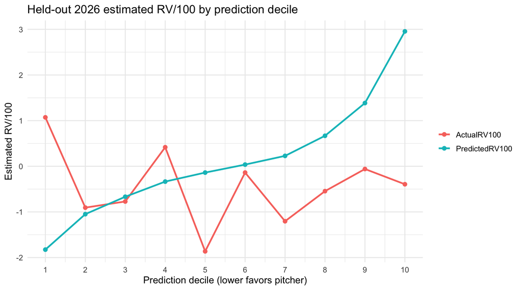

```r
selected_validation <- validation_predictions %>%
  filter(Threshold == params$similarity_threshold) %>%
  mutate(PredictionDecile = ntile(PredictedRV, 10))
validation_deciles <- selected_validation %>%
  group_by(PredictionDecile) %>% summarise(
    Pitches = n(), PredictedRV100 = 100 * mean(PredictedRV),
    ActualRV100 = 100 * mean(ActualRV), .groups = "drop")
validation_deciles %>%
  pivot_longer(c(PredictedRV100, ActualRV100), names_to = "Series", values_to = "RV100") %>%
  ggplot(aes(PredictionDecile, RV100, color = Series)) +
  geom_line(linewidth = 1) + geom_point(size = 2) +
  scale_x_continuous(breaks = 1:10) +
  labs(
    title = "Held-out 2026 estimated RV/100 by prediction decile",
    x = "Prediction decile (lower favors pitcher)", y = "Estimated RV/100", color = NULL) + theme_minimal(base_size = 12)
```

# Limitations

TrackMan player IDs are unavailable, so players are matched through normalized names. This preserves history across transfers and spelling variations, but two different players with the same normalized name could be combined. Rows without usable player identities are excluded from hitter-outcome modeling.

The run-value estimate is based on count transitions and approximate terminal-event weights because complete base-out state is unavailable. It is best interpreted as a relative matchup measure for comparing bullpen options under the same settings, rather than an official run-value statistic or a forecast of a single plate appearance.

Spin axis is unavailable, and plate location is intentionally excluded so similarity describes pitch shape rather than execution. Early-season arsenals and hitter samples can also be limited. Similarity coverage, sample size, pitch-family detail, and held-out validation should therefore be reviewed with every recommendation.

# Reading the output

`ProjectedRV100` is estimated context-neutral runs created by the batter per 100 pitches against similar pitch shapes, after weighting by the selected pitcher’s current usage. Lower values favor the pitcher.

`SimilarityCoverage` is the proportion of pitcher usage supported by at least 25 historical matches. Review low-coverage recommendations cautiously.

RV/100 is an estimate rather than official Statcast or MLB run value because complete base-out state is unavailable. Use it to compare pitchers against the same hitter or lineup. Whiff rate, hard-hit rate, wOBA, sample size and pitch-family detail explain why the ranking favors a pitcher.